# Presos-Droga-caplibro

Lo que necesitamos de datos del SNEEP es lo siguiente: 1. Cantidad de presos por estupefacientes en las cárceles de las provincias que desfederalizaron (desde los años correspondientes) sobre el total de presos y calcular el porcentaje; 2. Cantidad de mujeres presas por drogas en las cárceles de las provincias que desfederalización, sobre el total de presos por drogas y sobre el total de mujeres presas,

Provincia, Año, Cantidad total de presxs, cantidad varones cantidad mujeres, cantidad de presos por ley de estupefacientes cantidad varones cantidad mujeres, y cuanto representan los presos de drogas sobre el total de presos

```r
library(dplyr)
library(ggplot2)
library(tidyverse)
library(readr)
SNEEP <- read_csv("~/Desktop/Data/Work/PE/presos/costos23737/SNEEP-analisis/sneep-unificado-2002-2018.csv")
```

[output not shown]

```r
table(SNEEP %>% filter(provincia_descripcion=='Ciudad de Buenos Aires') %>% select(establecimiento_descripcion))
```

```
 SPF - COMPLEJO PENIT. FEDERAL DE LA CIUDAD DE BUENOS AIRES        SPF - U.18 CASA DE PREEGRESO ""DR. JOSE INGENIEROS""
                                                      30255                                                          81
         SPF - U.18 CASA DE PREEGRESO "DR. JOSE INGENIEROS"        SPF - U.20 SERVICIO PSIQUIATRICO  CENTRAL DE VARONES
                                                         16                                                        1008
SPF - U.21 CENTRO PENITENCIARIO DE ENFERMEDADES INFECCIOSAS         SPF - U.27 SERVICIO PSIQUIATRICO CENTRAL DE MUJERES
                                                        331                                                         116
                    SPF - U.28 CENTRO DE DETENCION JUDICIAL
                                                          2
```

```r
sneep_ligero <- SNEEP %>% select(c(anio_censo,provincia_descripcion,situacion_legal_descripcion,jurisdiccion_descripcion,establecimiento_descripcion,genero_descripcion,ultimo_lugar_residencia_descripcion,ultima_provincia_residencia_descripcion,fecha_detencion,fecha_condenado,delito1_descripcion,delito2_descripcion,delito3_descripcion,delito4_descripcion,delito5_descripcion))

table(sneep_ligero$jurisdiccion_descripcion, sneep_ligero$situacion_legal_descripcion)
```

```
                                        Condenado Contraventor Inimputable Otra situación Procesado
  FEDERAL                                   25808           11          28             61     57196
  Justicia de la Ciudad de Buenos Aires        51            0           0              1        70
  NACIONAL - Ciudad de Buenos Aires         46971            0         421             64     47461
  PROVINCIAL - Buenos Aires                166689           15        4780           3167    265956
  PROVINCIAL - Catamarca                     4790            0           0              6      2717
  PROVINCIAL - Chaco                        12111           60          27             14      4575
  PROVINCIAL - Chubut                        3543            1           8             13      1767
  PROVINCIAL - Córdoba                      49117           14          13              6     51887
  PROVINCIAL - Corrientes                    8686           16         349             58      4626
  PROVINCIAL - Entre Rios                   13835            6          42              0      2973
  PROVINCIAL - Formosa                       3470            0         130              4      3080
  PROVINCIAL - Jujuy                         5093            0           2              6      4436
  PROVINCIAL - La Pampa                      3863            1          11            341      1520
  PROVINCIAL - La Rioja                      2415           36          51            180      1614
  PROVINCIAL - Mendoza                      22485            0           2              0     13302
  PROVINCIAL - Misiones                     10520            0         658            405      7067
  PROVINCIAL - Neuquén                       6679            0           6             19      2802
  PROVINCIAL - Rio Negro                     9038            0           5              1      3206
  PROVINCIAL - Salta                        20661            0         577            354     13633
  PROVINCIAL - San Juan                      7834            0           1              3      6516
  PROVINCIAL - San Luis                      3608            2           0              0      3675
  PROVINCIAL - Santa Cruz                    2557            9           4             31      1559
  PROVINCIAL - Santa Fe                     30101            0          23             36     16744
  PROVINCIAL - Santiago del Estero           4413            0           3              1      2719
  PROVINCIAL - Tierra del Fuego              1532            0           0              0       732
  PROVINCIAL - Tucumán                       7199           47           4            102      9072
```

```r
table(sneep_ligero$provincia_descripcion, sneep_ligero$situacion_legal_descripcion)
```

```
                         Condenado Contraventor Inimputable Otra situación Procesado
  Buenos Aires              190374           14        4856           3258    322522
  Catamarca                   4809            0           0              3      2603
  Chaco                      19045           60          23             12      6684
  Chubut                     10824            2           2             13      2746
  Ciudad de Buenos Aires      6565            0         414             24     24806
  Córdoba                    50116           14           0              0     55729
  Corrientes                  8574           17         348             76      4738
  Entre Rios                 14481            6          45              0      4940
  Formosa                     4456            0         120              5      3678
  Jujuy                       6126            0           3             14      6727
  La Pampa                    8247            1          12            362      2367
  La Rioja                    2494           45          46            186      1688
  Mendoza                    32481            0           0             68     21681
  Misiones                   12760            0         658            421      8682
  Neuquén                    10477            0           0             19      3184
  Río Negro                  16637            0           5              1      3752
  Salta                      22747            0         599            373     17894
  San Juan                    8154            0           1              3      7533
  San Luis                    4048            2           0              0      4141
  Santa Cruz                  3441            9           3             35      1847
  Santa Fe                   31484            0          23             37     17957
  Santiago del Estero         4719            1           0              1      3442
  Tierra del Fuego            1541            0           0              0       825
  Tucumán                     7505           47           4            130      9768
```

```r
sneep_ligero_drogas <- sneep_ligero %>% filter((delito1_descripcion=='Infracción ley n° 23.737 (estupefacientes)' |
                                               delito2_descripcion=='Infracción ley n° 23.737 (estupefacientes)' |
                                               delito3_descripcion=='Infracción ley n° 23.737 (estupefacientes)' |
                                               delito4_descripcion=='Infracción ley n° 23.737 (estupefacientes)' |
                                               delito5_descripcion=='Infracción ley n° 23.737 (estupefacientes)')
                                               &
                   (!(grepl("FEDERAL",establecimiento_descripcion)) & !(grepl("SPF",establecimiento_descripcion)))
                                               &
        (jurisdiccion_descripcion != 'FEDERAL' & jurisdiccion_descripcion != 'NACIONAL - Ciudad de Buenos Aires'))

table(sneep_ligero_drogas$jurisdiccion_descripcion, sneep_ligero_drogas$situacion_legal_descripcion)
```

```
                                   Condenado Contraventor Inimputable Otra situación Procesado
  PROVINCIAL - Buenos Aires             9032            2          11            301     21351
  PROVINCIAL - Catamarca                  25            0           0              0       104
  PROVINCIAL - Chaco                     128            0           0              1       158
  PROVINCIAL - Chubut                     19            0           0              1        82
  PROVINCIAL - Córdoba                  1389            0           0              0      3171
  PROVINCIAL - Corrientes                  8            0           0              1        24
  PROVINCIAL - Entre Rios                 85            0           0              0        28
  PROVINCIAL - Formosa                    50            0           0              0       282
  PROVINCIAL - Jujuy                      33            0           0              0        12
  PROVINCIAL - La Pampa                    2            0           0              4        25
  PROVINCIAL - La Rioja                    2            0           0             19         6
  PROVINCIAL - Mendoza                   151            0           0              0       197
  PROVINCIAL - Misiones                   30            0           1              5        84
  PROVINCIAL - Neuquén                    21            0           0              0        38
  PROVINCIAL - Rio Negro                  51            0           0              0        16
  PROVINCIAL - Salta                    1404            0           0              1      1526
  PROVINCIAL - San Juan                  244            0           0              0       199
  PROVINCIAL - San Luis                   28            0           0              0        55
  PROVINCIAL - Santa Cruz                 20            0           0              0        34
  PROVINCIAL - Santa Fe                  372            0           0              2       505
  PROVINCIAL - Santiago del Estero        17            0           0              0        84
  PROVINCIAL - Tierra del Fuego           21            0           0              0        48
  PROVINCIAL - Tucumán                   128            0           0              0       226
```

```r
table(sneep_ligero_drogas$provincia_descripcion, sneep_ligero_drogas$situacion_legal_descripcion)
```

```
                      Condenado Contraventor Inimputable Otra situación Procesado
  Buenos Aires             9025            2          11            300     21363
  Catamarca                  25            0           0              0        92
  Chaco                     125            0           0              1       156
  Chubut                     19            0           0              1        87
  Córdoba                  1387            0           0              0      3172
  Corrientes                  5            0           0              3        26
  Entre Rios                 81            0           0              0        31
  Formosa                    43            0           0              0       280
  Jujuy                      31            0           0              0        16
  La Pampa                    2            0           0              4        25
  La Rioja                    3            0           0             19         6
  Mendoza                   149            0           0              0       195
  Misiones                   33            0           1              4        83
  Neuquén                    28            0           0              0        47
  Río Negro                  51            0           0              0        13
  Salta                    1429            0           0              1      1524
  San Juan                  243            0           0              0       201
  San Luis                   27            0           0              0        55
  Santa Cruz                 20            0           0              0        28
  Santa Fe                  372            0           0              2       491
  Santiago del Estero        14            0           0              0        83
  Tierra del Fuego           20            0           0              0        48
  Tucumán                   128            0           0              0       233
```

```r
# OJO CON ESTO (PROVINCIAS Y JURISDICCIONES)
sneep_ligero_drogas %>% group_by(provincia_descripcion,jurisdiccion_descripcion) %>% summarise(cantidad=n())
```

| provincia_descripcion | jurisdiccion_descripcion | cantidad |
| --- | --- | --- |
| Buenos Aires | PROVINCIAL - Buenos Aires | 30662 |
| Buenos Aires | PROVINCIAL - Catamarca | 10 |
| Buenos Aires | PROVINCIAL - Chaco | 1 |
| Buenos Aires | PROVINCIAL - Córdoba | 1 |
| Buenos Aires | PROVINCIAL - Corrientes | 3 |
| Buenos Aires | PROVINCIAL - Entre Rios | 1 |
| Buenos Aires | PROVINCIAL - Mendoza | 2 |
| Buenos Aires | PROVINCIAL - Misiones | 1 |
| Buenos Aires | PROVINCIAL - San Luis | 1 |
| Buenos Aires | PROVINCIAL - Santa Fe | 16 |

[output cut: 74 more lines]

```r
# BUENO, A VER LAS DISTRIBUCIONES
table(sneep_ligero_drogas$jurisdiccion_descripcion, sneep_ligero_drogas$anio_censo)
```

```
                                   2002 2003 2004 2005 2006 2007 2008 2009 2010 2011 2012 2013 2014 2015 2016 2017 2018
  PROVINCIAL - Buenos Aires          39   15   40   12  337 1013 1462 1696 2115 2500 2534 2547 2435 2617 2642 3732 4961
  PROVINCIAL - Catamarca              5    4    1    1   18    1    1   45    0    2    1   40    3    3    2    0    2
  PROVINCIAL - Chaco                  0    1   37   18    1    0    4    6    6    2    4    2    0    3   44   75   84
  PROVINCIAL - Chubut                 5    9   19    0    1    3    0    3    0    6    3   16    2    6    7   14    8
  PROVINCIAL - Córdoba                6   17    5    6   10    9    4   11    3    9   33  378  398  433 1450  782 1006
  PROVINCIAL - Corrientes             1    0    0    3    0    0   13    0    1    0    2    0    1    3    0    6    3
  PROVINCIAL - Entre Rios             2    1    4    5    2    1    1    2    1    1    5   16    4    3    8   13   44
  PROVINCIAL - Formosa               13   12    8    5    5    2    1    0    1    2    2    1    8    2   52   99  119
  PROVINCIAL - Jujuy                 31    2    2    2    3    2    1    0    1    1    0    0    0    0    0    0    0
  PROVINCIAL - La Pampa               1    0    1    2    0    0    0    0    8    4    0    2    0    1    2    5    5
  PROVINCIAL - La Rioja               0   10   13    0    1    0    0    1    0    1    1    0    0    0    0    0    0
  PROVINCIAL - Mendoza               10   72   17    1    0    0    0    0    0   51   11   42   23   46   32   20   23
  PROVINCIAL - Misiones              16   21    7    4    8    4    2    2    6   11    3   12    7    2    4   10    1
  PROVINCIAL - Neuquén               10   33    3    1    0    5    4    1    0    0    0    0    1    0    0    1    0
  PROVINCIAL - Rio Negro              1    2    0    4    1    0    2    0    0    2    0    5    6    4    4   23   13
  PROVINCIAL - Salta                  3    3  252  136  226  239  208    0    0   54   28    2  250  342  389  395  404
  PROVINCIAL - San Juan              13   27   48    5   10    1   10   10    3    2    6    5   19    0   45   58  181
  PROVINCIAL - San Luis              10   12   10    8    1    1    2    0    0    0    1    1    6    9   13    1    8
  PROVINCIAL - Santa Cruz             3    1    4    3    0    0    3    6    1    0    1    1    3    9    3    5   11
  PROVINCIAL - Santa Fe              40   44   47   16   17    2   19   65   12   16   39   47   11   37   58  374   35
  PROVINCIAL - Santiago del Estero    3    0   11    2   19   12    0    1   13    9    1   14   10    5    1    0    0
  PROVINCIAL - Tierra del Fuego       6    7    6    0    0    0    1    9    2    7    0    1    6    4    8   12    0
  PROVINCIAL - Tucumán               50    8   29   45   33    8    4    9   16   76   23    7    3    7    4   13   19
```

```r
# cambio las fechas
sneep_ligero_drogas['fecha_detencion_date'] <- str_remove(sneep_ligero_drogas$fecha_detencion,' 00:00:00')
sneep_ligero_drogas['fecha_detencion_date'] <- as.Date(sneep_ligero_drogas$fecha_detencion_date, "%d/%m/%Y")
sneep_ligero['fecha_detencion_date'] <- str_remove(sneep_ligero$fecha_detencion,' 00:00:00')
sneep_ligero['fecha_detencion_date'] <- as.Date(sneep_ligero$fecha_detencion_date, "%d/%m/%Y")
```

```r
table(provincia = sneep_ligero_drogas$provincia_descripcion, anio = sneep_ligero_drogas$anio_censo)
```

```
                     anio
provincia             2002 2003 2004 2005 2006 2007 2008 2009 2010 2011 2012 2013 2014 2015 2016 2017 2018
  Buenos Aires          36    9   35    7  334 1011 1463 1696 2113 2502 2539 2544 2441 2624 2648 3732 4967
  Catamarca              4    4    1    1   17    1    1   45    0    0    1   40    1    1    0    0    0
  Chaco                  0    1   36   17    1    0    3    6    7    2    3    2    0    3   44   74   83
  Chubut                 4    9   18    0    1    3    0    3    0    6    3   16    2    6    7   14   15
  Córdoba               12   18    4    4    9    8    4   12    3    9   31  377  398  433 1450  781 1006
  Corrientes             1    0    0    3    0    0   13    0    0    0    2    0    1    0    0   11    3
  Entre Rios             1    1    3    5    2    1    0    1    0    1    5   20    3    4    8   13   44
  Formosa                1   13    8    5    6    2    1    0    1    2    2    1    8    2   52   99  120
  Jujuy                 33    5    0    1    1    2    2    0    1    1    0    0    0    1    0    0    0
  La Pampa               1    0    1    2    0    0    0    0    8    4    0    2    0    1    2    5    5
  La Rioja               0   10   13    0    1    0    1    1    0    1    1    0    0    0    0    0    0
  Mendoza                9   73   16    1    0    0    0    0    0   51   11   42   21   45   32   20   23
  Misiones              16   22    8    4    7    4    3    2    7   11    2   13    7    2    4    9    0
  Neuquén               22   37    3    1    0    5    4    1    0    0    0    0    1    0    0    1    0
  Río Negro              1    0    0    3    1    0    2    0    0    2    0    5    6    4    4   23   13
  Salta                  2    0  262  140  232  243  209    0    0   56   28    2  250  342  389  395  404
  San Juan              13   26   48    5   10    1   10   10    3    2    6    5   19    0   45   58  183
  San Luis              10   12   10    8    1    1    2    0    0    0    1    1    5    9   13    1    8
  Santa Cruz             3    1    4    3    0    0    3    6    1    0    1    1    3    9    3    5    5
  Santa Fe              43   45   48   15   18    1   17   65   12   16   38   46   10   36   54  372   29
  Santiago del Estero    2    0   11    2   19   12    0    1   13    9    0   14   10    3    1    0    0
  Tierra del Fuego       6    7    6    0    0    0    1    9    2    6    0    1    6    4    8   12    0
  Tucumán               48    8   29   52   33    8    3    9   18   75   24    7    4    7    4   13   19
```

```r
frecuencias_droga <- as.data.frame.matrix(table(provincia = sneep_ligero_drogas$provincia_descripcion, anio = sneep_ligero_drogas$anio_censo))
#frecuencias_droga_t <- as.data.frame.matrix(t(frecuencias_droga))

table(sneep_ligero_drogas$jurisdiccion_descripcion)
```

```
       PROVINCIAL - Buenos Aires           PROVINCIAL - Catamarca               PROVINCIAL - Chaco              PROVINCIAL - Chubut
                           30697                              129                              287                              102
            PROVINCIAL - Córdoba          PROVINCIAL - Corrientes          PROVINCIAL - Entre Rios             PROVINCIAL - Formosa
                            4560                               33                              113                              332
              PROVINCIAL - Jujuy            PROVINCIAL - La Pampa            PROVINCIAL - La Rioja             PROVINCIAL - Mendoza
                              45                               31                               27                              348
           PROVINCIAL - Misiones             PROVINCIAL - Neuquén           PROVINCIAL - Rio Negro               PROVINCIAL - Salta
                             120                               59                               67                             2931
           PROVINCIAL - San Juan            PROVINCIAL - San Luis          PROVINCIAL - Santa Cruz            PROVINCIAL - Santa Fe
                             443                               83                               54                              879
PROVINCIAL - Santiago del Estero    PROVINCIAL - Tierra del Fuego             PROVINCIAL - Tucumán
                             101                               69                              354
```

```r
table(sneep_ligero_drogas$provincia_descripcion)
```

```
       Buenos Aires           Catamarca               Chaco              Chubut             Córdoba          Corrientes          Entre Rios
              30701                 117                 282                 107                4559                  34                 112
            Formosa               Jujuy            La Pampa            La Rioja             Mendoza            Misiones             Neuquén
                323                  47                  31                  28                 344                 121                  75
          Río Negro               Salta            San Juan            San Luis          Santa Cruz            Santa Fe Santiago del Estero
                 64                2954                 444                  82                  48                 865                  97
   Tierra del Fuego             Tucumán
                 68                 361
```

Hacer para cada una de las provincias en cuestion, agarrar solo los que tienen fecha_detencion > a la fecha de la ley

- Buenos Aires : 2/12/2005
- Cordoba : 1/12/2012
- Salta : 1/1/2014
- Chaco : 6/5/2015
- Formosa : 15/10/2015
- Entre Rios : 13/5/2018
- Santiago : 15/9/2018
- CABA : 1/1/2019
- Tucuman : 1/9/2020 **ver**

```r
sneep_provs <- sneep_ligero_drogas %>% filter((jurisdiccion_descripcion=='PROVINCIAL - Buenos Aires' & fecha_detencion_date > as.Date("2005-12-2")) |
                                              (jurisdiccion_descripcion=='PROVINCIAL - Córdoba' & fecha_detencion_date > as.Date("2012-12-1")) |
                                              (jurisdiccion_descripcion=='PROVINCIAL - Salta' & fecha_detencion_date > as.Date("2014-01-1")) |
                                              (jurisdiccion_descripcion=='PROVINCIAL - Chaco' & fecha_detencion_date > as.Date("2015-05-6")) |
                                              (jurisdiccion_descripcion=='PROVINCIAL - Formosa' & fecha_detencion_date > as.Date("2015-10-15")) |
                                              (jurisdiccion_descripcion=='PROVINCIAL - Entre Rios' & fecha_detencion_date > as.Date("2018-05-13")) |
                                              (jurisdiccion_descripcion=='PROVINCIAL - Santiago del Estero' & fecha_detencion_date > as.Date("2018-09-15")) |
                                              (jurisdiccion_descripcion=='PROVINCIAL - Buenos Aires' & fecha_detencion_date > as.Date("2019-1-1"))
                                              )

table(sneep_provs$jurisdiccion_descripcion)
```

```
PROVINCIAL - Buenos Aires        PROVINCIAL - Chaco      PROVINCIAL - Córdoba   PROVINCIAL - Entre Rios      PROVINCIAL - Formosa
                    26891                       194                      3811                        24                       267
       PROVINCIAL - Salta
                     1553
```

```r
sneep_provs2 <- sneep_ligero_drogas %>% filter((provincia_descripcion=='Buenos Aires' & fecha_detencion_date > as.Date("2005-12-2")) |
                                              (provincia_descripcion=='Córdoba' & fecha_detencion_date > as.Date("2012-12-1")) |
                                              (provincia_descripcion=='Salta' & fecha_detencion_date > as.Date("2014-01-1")) |
                                              (provincia_descripcion=='Chaco' & fecha_detencion_date > as.Date("2015-05-6")) |
                                              (provincia_descripcion=='Formosa' & fecha_detencion_date > as.Date("2015-10-15")) |
                                              (provincia_descripcion=='Entre Rios' & fecha_detencion_date > as.Date("2018-05-13")) |
                                              (provincia_descripcion=='Santiago del Estero' & fecha_detencion_date > as.Date("2018-09-15")) |
                                              (provincia_descripcion=='Buenos Aires' & fecha_detencion_date > as.Date("2019-1-1")) )

table(sneep_provs2$provincia_descripcion)
```

```
Buenos Aires        Chaco      Córdoba   Entre Rios      Formosa        Salta
       26917          192         3810           24          268         1553
```

Provincia, Año, Cantidad total de presxs, cantidad varones cantidad mujeres, cantidad de presos por ley de estupefacientes cantidad varones cantidad mujeres, y cuanto representan los presos de drogas sobre el total de presos

```r
# bueno ahora puedo hacer un super nice groupby y summarise
### ACLARACION: si bien filtre por el momento en el que entraron, aca estoy agrupando en el momento en el que se hizo el censo

# PRESOS
sneep_agrupado_23737 <- sneep_provs %>% group_by(jurisdiccion_descripcion,anio_censo) %>% summarise(
            presos_23737=n(), masculinos_23737=length(genero_descripcion[genero_descripcion=='Masculino']),
            femeninos_23737=length(genero_descripcion[genero_descripcion=='Femenino']))
# TOTAL
sneep_total_filtrado <- sneep_ligero %>% filter((jurisdiccion_descripcion=='PROVINCIAL - Buenos Aires' & fecha_detencion_date > as.Date("2005-12-2")) |
                                              (jurisdiccion_descripcion=='PROVINCIAL - Córdoba' & fecha_detencion_date > as.Date("2012-12-1")) |
                                              (jurisdiccion_descripcion=='PROVINCIAL - Salta' & fecha_detencion_date > as.Date("2014-01-1")) |
                                              (jurisdiccion_descripcion=='PROVINCIAL - Chaco' & fecha_detencion_date > as.Date("2015-05-6")) |
                                              (jurisdiccion_descripcion=='PROVINCIAL - Formosa' & fecha_detencion_date > as.Date("2015-10-15")) |
                                              (jurisdiccion_descripcion=='PROVINCIAL - Entre Rios' & fecha_detencion_date > as.Date("2018-05-13")) |
                                              (jurisdiccion_descripcion=='PROVINCIAL - Santiago del Estero' & fecha_detencion_date > as.Date("2018-09-15")) |
                                              (jurisdiccion_descripcion=='PROVINCIAL - Buenos Aires' & fecha_detencion_date > as.Date("2019-1-1")))

sneep_agrupado_total <- sneep_total_filtrado %>% group_by(jurisdiccion_descripcion,anio_censo) %>% summarise(
            presos_total=n(), masculinos_total=length(genero_descripcion[genero_descripcion=='Masculino']),
            femeninos_total=length(genero_descripcion[genero_descripcion=='Femenino']))
sneep_agrupado_total <- sneep_agrupado_total %>% filter(!anio_censo %in% c(2002,2003))

sneep_agrupado_23737
```

| jurisdiccion_descripcion | anio_censo | presos_23737 | masculinos_23737 | femeninos_23737 |
| --- | --- | --- | --- | --- |
| PROVINCIAL - Buenos Aires | 2006 | 263 | 167 | 96 |
| PROVINCIAL - Buenos Aires | 2007 | 776 | 526 | 250 |
| PROVINCIAL - Buenos Aires | 2008 | 1197 | 864 | 333 |
| PROVINCIAL - Buenos Aires | 2009 | 1450 | 1055 | 395 |
| PROVINCIAL - Buenos Aires | 2010 | 1877 | 1448 | 429 |
| PROVINCIAL - Buenos Aires | 2011 | 2158 | 1658 | 500 |
| PROVINCIAL - Buenos Aires | 2012 | 2108 | 1724 | 384 |
| PROVINCIAL - Buenos Aires | 2013 | 2134 | 1738 | 396 |
| PROVINCIAL - Buenos Aires | 2014 | 2055 | 1716 | 339 |
| PROVINCIAL - Buenos Aires | 2015 | 2348 | 2031 | 317 |

[output cut: 24 more lines]

| jurisdiccion_descripcion | anio_censo | presos_total | masculinos_total | femeninos_total |
| --- | --- | --- | --- | --- |
| PROVINCIAL - Buenos Aires | 2005 | 179 | 178 | 1 |
| PROVINCIAL - Buenos Aires | 2006 | 3639 | 3422 | 217 |
| PROVINCIAL - Buenos Aires | 2007 | 7967 | 7476 | 491 |
| PROVINCIAL - Buenos Aires | 2008 | 11991 | 11343 | 648 |
| PROVINCIAL - Buenos Aires | 2009 | 14862 | 14055 | 807 |
| PROVINCIAL - Buenos Aires | 2010 | 18559 | 17638 | 921 |
| PROVINCIAL - Buenos Aires | 2011 | 20179 | 19132 | 1047 |
| PROVINCIAL - Buenos Aires | 2012 | 20715 | 19882 | 833 |
| PROVINCIAL - Buenos Aires | 2013 | 20919 | 19858 | 1061 |
| PROVINCIAL - Buenos Aires | 2014 | 24528 | 23394 | 1134 |

[output cut: 26 more lines]

```r
library(writexl)
```

Todo esto fue sin contar los que no tienen fecha de ingreso. Puedo probar haciendolo con el anio nada mas asi agarro a todos pero queda ruidoso. El 12% se pierde por no tener esa fecha

```r
sum(is.na(sneep_ligero$fecha_detencion_date)) / (sum(!is.na(sneep_ligero$fecha_detencion_date)) + sum(is.na(sneep_ligero$fecha_detencion_date)))
```

```
[1] 0.1221801
```

Arranco de sneep_ligero_drogas y filtro en vez de fecha_detencion_date por anio_censo (el mas cercano a la fecha posta)

- Buenos Aires : 2/12/2005
- Cordoba : 1/12/2012
- Salta : 1/1/2014
- Chaco : 6/5/2015
- Formosa : 15/10/2015
- Entre Rios : 13/5/2018
- Santiago : 15/9/2018
- CABA : 1/1/2019
- Tucuman : 1/9/2020 **ver**

```r
sneep_provs2 <- sneep_ligero_drogas %>% filter((jurisdiccion_descripcion=='PROVINCIAL - Buenos Aires' & anio_censo>=2006) |
                                              (jurisdiccion_descripcion=='PROVINCIAL - Córdoba' & anio_censo>=2012) |
                                              (jurisdiccion_descripcion=='PROVINCIAL - Salta' & anio_censo>=2014) |
                                              (jurisdiccion_descripcion=='PROVINCIAL - Chaco' & anio_censo>=2015) |
                                              (jurisdiccion_descripcion=='PROVINCIAL - Formosa' & anio_censo>=2015) |
                                              (jurisdiccion_descripcion=='PROVINCIAL - Entre Rios' & anio_censo>=2018) |
                                              (jurisdiccion_descripcion=='PROVINCIAL - Santiago del Estero' & anio_censo>=2018))

table(sneep_provs2$jurisdiccion_descripcion)
```

```
PROVINCIAL - Buenos Aires        PROVINCIAL - Chaco      PROVINCIAL - Córdoba   PROVINCIAL - Entre Rios      PROVINCIAL - Formosa
                    30591                       206                      4480                        44                       272
       PROVINCIAL - Salta
                     1780
```

```r
# PRESOS (les agrego los porcentajes de situacion legal)
sneep_agrupado_23737_2 <- sneep_provs2 %>% group_by(jurisdiccion_descripcion,anio_censo) %>% summarise(
            presos_23737=n(), masculinos_23737=length(genero_descripcion[genero_descripcion=='Masculino']),
            femeninos_23737=length(genero_descripcion[genero_descripcion=='Femenino']),
            condenados_23737=length(situacion_legal_descripcion[situacion_legal_descripcion=='Condenado']),
            procesados_23737=length(situacion_legal_descripcion[situacion_legal_descripcion=='Procesado']))
# TOTAL
sneep_total_filtrado2 <- sneep_ligero %>% filter((jurisdiccion_descripcion=='PROVINCIAL - Buenos Aires' & anio_censo>=2006) |
                                              (jurisdiccion_descripcion=='PROVINCIAL - Córdoba' & anio_censo>=2012) |
                                              (jurisdiccion_descripcion=='PROVINCIAL - Salta' & anio_censo>=2014) |
                                              (jurisdiccion_descripcion=='PROVINCIAL - Chaco' & anio_censo>=2015) |
                                              (jurisdiccion_descripcion=='PROVINCIAL - Formosa' & anio_censo>=2015) |
                                              (jurisdiccion_descripcion=='PROVINCIAL - Entre Rios' & anio_censo>=2018) |
                                              (jurisdiccion_descripcion=='PROVINCIAL - Santiago del Estero' & anio_censo>=2018))



sneep_agrupado_total_2 <- sneep_total_filtrado2 %>% group_by(jurisdiccion_descripcion,anio_censo) %>% summarise(
            presos_total=n(), masculinos_total=length(genero_descripcion[genero_descripcion=='Masculino']),
            femeninos_total=length(genero_descripcion[genero_descripcion=='Femenino']),
            condenados_total=length(situacion_legal_descripcion[situacion_legal_descripcion=='Condenado']),
            procesados_total=length(situacion_legal_descripcion[situacion_legal_descripcion=='Procesado']))

sneep_agrupado_23737_2
```

| jurisdiccion_descripcion | anio_censo | presos_23737 | masculinos_23737 | femeninos_23737 | condenados_23737 | procesados_23737 |
| --- | --- | --- | --- | --- | --- | --- |
| PROVINCIAL - Buenos Aires | 2006 | 337 | 235 | 102 | 13 | 324 |
| PROVINCIAL - Buenos Aires | 2007 | 1013 | 733 | 280 | 57 | 950 |
| PROVINCIAL - Buenos Aires | 2008 | 1462 | 1074 | 388 | 201 | 1257 |
| PROVINCIAL - Buenos Aires | 2009 | 1696 | 1291 | 405 | 383 | 1300 |
| PROVINCIAL - Buenos Aires | 2010 | 2115 | 1679 | 436 | 571 | 1541 |
| PROVINCIAL - Buenos Aires | 2011 | 2500 | 1992 | 508 | 741 | 1744 |
| PROVINCIAL - Buenos Aires | 2012 | 2534 | 1991 | 543 | 746 | 1749 |
| PROVINCIAL - Buenos Aires | 2013 | 2547 | 2141 | 406 | 864 | 1644 |
| PROVINCIAL - Buenos Aires | 2014 | 2435 | 2094 | 341 | 766 | 1629 |
| PROVINCIAL - Buenos Aires | 2015 | 2617 | 2291 | 326 | 817 | 1754 |

[output cut: 24 more lines]

| jurisdiccion_descripcion | anio_censo | presos_total | masculinos_total | femeninos_total | condenados_total | procesados_total |
| --- | --- | --- | --- | --- | --- | --- |
| PROVINCIAL - Buenos Aires | 2006 | 20548 | 19794 | 754 | 4366 | 15648 |
| PROVINCIAL - Buenos Aires | 2007 | 21930 | 21078 | 852 | 4545 | 16841 |
| PROVINCIAL - Buenos Aires | 2008 | 23283 | 22333 | 950 | 5586 | 17230 |
| PROVINCIAL - Buenos Aires | 2009 | 23342 | 22374 | 968 | 7234 | 15631 |
| PROVINCIAL - Buenos Aires | 2010 | 26255 | 25160 | 1095 | 10059 | 15706 |
| PROVINCIAL - Buenos Aires | 2011 | 27132 | 25929 | 1203 | 11158 | 15455 |
| PROVINCIAL - Buenos Aires | 2012 | 27143 | 25944 | 1199 | 11481 | 15172 |
| PROVINCIAL - Buenos Aires | 2013 | 28135 | 27002 | 1133 | 12452 | 15145 |
| PROVINCIAL - Buenos Aires | 2014 | 30475 | 29279 | 1196 | 13371 | 16484 |
| PROVINCIAL - Buenos Aires | 2015 | 31878 | 30726 | 1152 | 14626 | 16722 |

[output cut: 25 more lines]

```r
library(writexl)
write_xlsx(sneep_agrupado_23737_2, '/Users/lucaspecina/Desktop/Data/Work/PE/presos/costos23737/Capitulo libro/sneep_agrupado_23737_AÑO_situacion.xlsx')
write_xlsx(sneep_agrupado_total_2, '/Users/lucaspecina/Desktop/Data/Work/PE/presos/costos23737/Capitulo libro/sneep_agrupado_total_AÑO_situacion.xlsx')
```

ver si se puede hacer un test para la diferencia de condenados/procesados - quiero tener dos grupos: droga y no droga - quiero sacar la diferencia entre los procesados y condenados para cada grupo (estandarizados) - hacer t-test simple

```r
# NO DROGAS

sneep_ligero_nodrogas <- sneep_ligero %>% filter(((delito1_descripcion!='Infracción ley n° 23.737 (estupefacientes)' | is.na(delito1_descripcion)) &
                                               (delito2_descripcion!='Infracción ley n° 23.737 (estupefacientes)' | is.na(delito2_descripcion)) &
                                               (delito3_descripcion!='Infracción ley n° 23.737 (estupefacientes)' | is.na(delito3_descripcion)) &
                                               (delito4_descripcion!='Infracción ley n° 23.737 (estupefacientes)' | is.na(delito4_descripcion)) &
                                               (delito5_descripcion!='Infracción ley n° 23.737 (estupefacientes)' | is.na(delito5_descripcion)))
                                               &
                   (!(grepl("FEDERAL",establecimiento_descripcion)) & !(grepl("SPF",establecimiento_descripcion)))
                                               &
        (jurisdiccion_descripcion != 'FEDERAL' & jurisdiccion_descripcion != 'NACIONAL - Ciudad de Buenos Aires'))



sneep_nodrogas_filtrado2 <- sneep_ligero_nodrogas %>% filter((jurisdiccion_descripcion=='PROVINCIAL - Buenos Aires' & anio_censo>=2006) |
                                              (jurisdiccion_descripcion=='PROVINCIAL - Córdoba' & anio_censo>=2012) |
                                              (jurisdiccion_descripcion=='PROVINCIAL - Salta' & anio_censo>=2014) |
                                              (jurisdiccion_descripcion=='PROVINCIAL - Chaco' & anio_censo>=2015) |
                                              (jurisdiccion_descripcion=='PROVINCIAL - Formosa' & anio_censo>=2015) |
                                              (jurisdiccion_descripcion=='PROVINCIAL - Entre Rios' & anio_censo>=2018) |
                                              (jurisdiccion_descripcion=='PROVINCIAL - Santiago del Estero' & anio_censo>=2018))



sneep_agrupado_nodroga_2 <- sneep_nodrogas_filtrado2 %>% group_by(jurisdiccion_descripcion,anio_censo) %>% summarise(
            presos_no23737=n(),
            masculinos_no23737=length(genero_descripcion[genero_descripcion=='Masculino']),
            femeninos_no23737=length(genero_descripcion[genero_descripcion=='Femenino']),
            condenados_no23737=length(situacion_legal_descripcion[situacion_legal_descripcion=='Condenado']),
            procesados_no23737=length(situacion_legal_descripcion[situacion_legal_descripcion=='Procesado']))
```

```r
# JOIN

droga_nodroga <- sneep_agrupado_nodroga_2 %>% inner_join(sneep_agrupado_23737_2, on= c("jurisdiccion_descripcion" = "jurisdiccion_descripcion",
                                                                                        "anio_censo" = "anio_censo"))
# CALCULO DIFERENCIAS RELATIVAS
droga_nodroga <- droga_nodroga %>% mutate(condenados_no23737_relat=condenados_no23737/(procesados_no23737+condenados_no23737),
                                          procesados_no23737_relat=procesados_no23737/(procesados_no23737+condenados_no23737),
                                          condenados_23737_relat=condenados_23737/(procesados_23737+condenados_23737),
                                          procesados_23737_relat=procesados_23737/(procesados_23737+condenados_23737))
 #              %>%   mutate(sit_dif_no23737=procesados_no23737_relat - condenados_no23737_relat,
 #                    sit_dif_23737=procesados_23737_relat - condenados_23737_relat)

droga_nodroga <- droga_nodroga %>% filter(procesados_23737+condenados_23737 > 40) %>% filter(anio_censo>=2016)
```

[figure not shown]

```r
# PAIRED T-TEST PERO USANDO AÑOS
t.test(droga_nodroga$procesados_23737_relat,droga_nodroga$procesados_no23737_relat,paires=TRUE)
```

```
    Welch Two Sample t-test

data:  droga_nodroga$procesados_23737_relat and droga_nodroga$procesados_no23737_relat
t = 2.2393, df = 25.571, p-value = 0.03406
alternative hypothesis: true difference in means is not equal to 0
95 percent confidence interval:
 0.01516758 0.35781714
sample estimates:
mean of x mean of y
0.5727739 0.3862815
```

```r
# SOLO BUENOS AIRES
droga_nodroga_ba <- droga_nodroga %>% filter(jurisdiccion_descripcion=='PROVINCIAL - Buenos Aires')
t.test(droga_nodroga_ba$procesados_23737_relat,droga_nodroga_ba$procesados_no23737_relat,paired = TRUE)
```

```
    Paired t-test

data:  droga_nodroga_ba$procesados_23737_relat and droga_nodroga_ba$procesados_no23737_relat
t = 9.0228, df = 2, p-value = 0.01206
alternative hypothesis: true difference in means is not equal to 0
95 percent confidence interval:
 0.1022513 0.2886640
sample estimates:
mean of the differences
              0.1954577
```

```r
# PAIRED T-TEST AGREGADO POR AÑO (SOLO PROVINCIAS)
droga_nodroga_agg_test <- droga_nodroga %>% group_by(jurisdiccion_descripcion) %>%
  summarise(procesados_23737_relat=mean(procesados_23737_relat) , procesados_no23737_relat=mean(procesados_no23737_relat))
t.test(droga_nodroga_agg_test$procesados_23737_relat , droga_nodroga_agg_test$procesados_no23737_relat,paired = TRUE)
```

```
    Paired t-test

data:  droga_nodroga_agg_test$procesados_23737_relat and droga_nodroga_agg_test$procesados_no23737_relat
t = 2.5275, df = 5, p-value = 0.05269
alternative hypothesis: true difference in means is not equal to 0
95 percent confidence interval:
 -0.002892653  0.342471030
sample estimates:
mean of the differences
              0.1697892
```

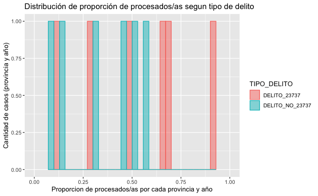

```r
droga_nodroga_agg <- droga_nodroga_gather %>% group_by(jurisdiccion_descripcion,TIPO_DELITO) %>%
    summarise(proporcion=mean(proporcion) )

ggplot(droga_nodroga_agg, aes(x=proporcion, color=TIPO_DELITO,fill=TIPO_DELITO)) +
  geom_histogram( alpha=0.5, position="identity") + ggtitle("Distribución de proporción de procesados/as segun tipo de delito") +
  xlab("Proporcion de procesados/as por cada provincia y año") + ylab("Cantidad de casos (provincia y año)") + coord_cartesian(xlim = c(0,1))
```